# 01 - EDA and Data Analysis

## Purpose

The purpose of this notebook is to explore and summarize the Liberty Mutual Commercial Property Fire-Peril Loss Cost dataset. Descriptive statistics and visualizations are used to understand the structure of the data, identify ke distributional characteristics and highlight patterns that are relevant for loss cost modelling.

## Methodology

The analysis begins with a high-level examination of the dataset structure. This includes the number of observations, predictor variables and data types. Descriptive statistics are computed for numeric variables. Skewness, Kurtosis and proportion of zero values is also computed.

Visualizations are used to examine the distribution of the fire-peril loss cost and assess the presence of outliers and non-linear patterns. These findings will help determine the choice of modelling techniques that will be used later.

## Dataset Overview

The dataset is representative of a typical commercial insurance dataset because there is extreme skewness, heavy tails and a large number of zeros. This makes it a strong candidate for GLMs (Tweedie/Gamma) and tree-based ensemble models.

## Data Loading

```python
# ======================================================
# CIND820 - Keystone Project
# Data Analysis and Visualization: Fire Peril Loss Cost (Liberty Mutual Insurance)
# Author: Debra Allen
# ======================================================

# Call Libraries
import pandas as pd
import numpy as np
import matplotlib.pyplot as plt
import seaborn as sns
import os
from pathlib import Path
```

```python
# ======================================================
# Load the dataset and display basic information
# ======================================================

def find_repo_root(start_path=None, marker_files=("'git", "README.md")):
    """
    Walk up the directory to find the repository root.
    The root is identified by the presence of marker files (e.g., .git, README.md).
    """
    if start_path is None:
        start_path = Path.cwd()

    start_path = start_path.resolve()

    for parent in [start_path] + list(start_path.parents):
        for marker in marker_files:
            if (parent / marker).exists():
                return parent
    raise FileNotFoundError("Could not find repo root. Run notebook from inside the repo.")


REPO_ROOT = find_repo_root()
DATA_PATH = REPO_ROOT / "data" / "liberty_train.csv"
print("Repo Root:", REPO_ROOT)
print("Data Path:", DATA_PATH)

# Read the dataset
data = pd.read_csv(DATA_PATH, low_memory=False)

# Display the first few rows of the dataset
print("\nFirst few rows of the dataset:")
data.head()
```

```
Repo Root: C:\Users\uni_f\Downloads\LaTex\TMU-CIND820
Data Path: C:\Users\uni_f\Downloads\LaTex\TMU-CIND820\data\liberty_train.csv

First few rows of the dataset:
```

|  | id | target | var1 | var2 | var3 | var4 | var5 | var6 | var7 | var8 | ... | weatherVar227 | weatherVar228 | weatherVar229 | weatherVar230 | weatherVar231 | weatherVar232 | weatherVar233 | weatherVar234 | weatherVar235 | weatherVar236 |
| --- | --- | --- | --- | --- | --- | --- | --- | --- | --- | --- | --- | --- | --- | --- | --- | --- | --- | --- | --- | --- | --- |
| 0 | 1 | 0.0 | Z | Z | Z | N1 | Z | Z | 3 | 1 | ... | 0.170351 | 0.0 | 0.00000 | 0.000000 | 1.117353 | 1.215303 | 0.112556 | 2.355737 | 0.404655 | 0.138667 |
| 1 | 2 | 0.0 | Z | Z | Z | C1 | Z | Z | 3 | 2 | ... | 0.266173 | 0.0 | 27.50823 | 0.000000 | 3.828979 | 1.036739 | 0.033052 | 0.856632 | 0.231232 | 0.742199 |
| 2 | 3 | 0.0 | 3 | Z | 4 | J3 | B | B | 2 | 4 | ... | 0.979517 | 0.0 | 0.00000 | 0.456134 | 0.098790 | 1.076535 | 0.566352 | 0.696013 | 0.693695 | 0.070654 |
| 3 | 4 | 0.0 | 3 | Z | 4 | H1 | B | Z | 3 | 4 | ... | 0.308761 | 0.0 | 0.00000 | 4.349042 | 0.401975 | 0.340631 | 0.290147 | 0.000000 | 0.000000 | 0.090332 |
| 4 | 5 | 0.0 | Z | Z | Z | H1 | Z | Z | 2 | 4 | ... | 2.171972 | 0.0 | 0.00000 | 0.514990 | 0.516095 | 1.016120 | 1.313732 | 1.338487 | 2.948202 | 0.816485 |

5 rows × 302 columns

```python
# Reduce the size of the Train dataset to 25 % as the memory is being fully exhausted
# The rows are selected randomly

train = data.sample(frac = .25, replace = False)
```

## Descriptive Statistics

```python
# Display basic structure of the dataset
print("\nDataset Info:")
train.info()

# Display the shape of the reduced dataset
print("\nDataset Shape:", train.shape)
```

```
Dataset Info:
<class 'pandas.DataFrame'>
Index: 113015 entries, 419258 to 337044
Columns: 302 entries, id to weatherVar236
dtypes: float64(291), int64(1), str(10)
memory usage: 261.3 MB

Dataset Shape: (113015, 302)
```

```python
# Display summary statistics of the dataset
print("\nSummary Statistics:")
train.describe()
```

```
Summary Statistics:
```

|  | id | target | var10 | var11 | var12 | var13 | var14 | var15 | var16 | var17 | ... | weatherVar227 | weatherVar228 | weatherVar229 | weatherVar230 | weatherVar231 | weatherVar232 | weatherVar233 | weatherVar234 | weatherVar235 | weatherVar236 |
| --- | --- | --- | --- | --- | --- | --- | --- | --- | --- | --- | --- | --- | --- | --- | --- | --- | --- | --- | --- | --- | --- |
| count | 113015.000000 | 113015.000000 | 113015.000000 | 113015.000000 | 24279.000000 | 113015.000000 | 40396.000000 | 88326.000000 | 22599.000000 | 113015.000000 | ... | 108319.000000 | 108319.000000 | 108319.000000 | 108319.000000 | 108319.000000 | 108319.000000 | 108319.000000 | 108319.000000 | 108319.000000 | 108319.000000 |
| mean | 451750.288652 | 0.006402 | 4.127684 | 1318.280709 | 3.100711 | 1.303204 | 0.228687 | 31.266632 | 73.729590 | 68.827526 | ... | 0.947606 | 0.989907 | 1.021631 | 0.962064 | 0.998040 | 1.013055 | 0.894513 | 1.072046 | 0.991828 | 1.027310 |
| std | 260978.850700 | 0.199941 | 0.310716 | 1090.386335 | 0.285221 | 0.814958 | 0.434429 | 25.553983 | 43.141477 | 37.183021 | ... | 0.732689 | 38.456667 | 3.958591 | 1.866445 | 3.356193 | 0.182688 | 1.073316 | 0.909407 | 1.367139 | 4.618792 |
| min | 1.000000 | 0.000000 | 3.742477 | 500.000000 | 0.000000 | 0.000000 | 0.000000 | 0.000000 | 0.000000 | 0.000000 | ... | 0.010647 | 0.000000 | 0.000000 | 0.000000 | 0.000000 | 0.000000 | 0.001047 | 0.000000 | 0.000000 | 0.000000 |
| 25% | 225680.500000 | 0.000000 | 3.898949 | 681.909085 | 2.937775 | 0.832555 | 0.000000 | 13.000000 | 18.000000 | 50.000000 | ... | 0.415230 | 0.000000 | 0.000000 | 0.000000 | 0.068131 | 0.910755 | 0.246716 | 0.374776 | 0.231232 | 0.029516 |
| 50% | 451574.000000 | 0.000000 | 4.039930 | 940.134565 | 3.099098 | 1.394959 | 0.000000 | 26.000000 | 100.000000 | 86.187845 | ... | 0.787872 | 0.000000 | 0.000000 | 0.334218 | 0.200987 | 1.060658 | 0.741385 | 0.856632 | 0.578079 | 0.120323 |
| 75% | 678247.500000 | 0.000000 | 4.314082 | 1497.998665 | 3.273289 | 1.945299 | 0.000000 | 42.000000 | 100.000000 | 100.000000 | ... | 1.288277 | 0.000000 | 0.000000 | 1.366301 | 0.669390 | 1.134062 | 1.230880 | 1.552645 | 1.213965 | 0.397248 |
| max | 902779.000000 | 18.985234 | 5.677710 | 14104.377710 | 3.939267 | 2.894981 | 2.150575 | 440.500000 | 100.000000 | 100.000000 | ... | 3.641247 | 3778.103919 | 171.926438 | 55.553810 | 137.327164 | 1.546449 | 50.053757 | 5.353948 | 8.093103 | 100.087491 |

8 rows × 292 columns

```python
# Display the data types of the columns in the dataset
print("\nData Types of Columns:")
train.dtypes
```

```
Data Types of Columns:
```

```
id                 int64
target           float64
var1                 str
var2                 str
var3                 str
                  ...
weatherVar232    float64
weatherVar233    float64
weatherVar234    float64
weatherVar235    float64
weatherVar236    float64
Length: 302, dtype: object
```

```python
# Compute mean, median, standard deviation, max, min and zero-rate
# of the target variable only in both the reduced and full datasets

if 'target' in train.columns:
    print('Mean Loss Cost - Reduced Dataset:', train['target'].mean())
    print('Median - Reduced Dataset:', train['target'].median())
    print('Standard Deviation - Reduced Dataset:', train['target'].std())
    print('Max - Reduced Dataset:', train['target'].max())
    print('Min - Reduced Dataset:', train['target'].min())
    perc_zero = (train['target'] == 0).mean() * 100
    print('Zero-rate - Reduced Dataset: {:.4f}%'.format(perc_zero))
else:
    print('train target column not found')

if 'target' in data.columns:
    print('\nMean Loss Cost - Full Dataset:', data['target'].mean())
    print('Median - Full Dataset:', data['target'].median())
    print('Standard Deviation - Full Dataset:', data['target'].std())
    print('Max - Full Dataset:', data['target'].max())
    print('Min - Full Dataset:', data['target'].min())
    perc_zero = (data['target'] == 0).mean() * 100
    print('Zero-rate - Full Dataset: {:.4f}%'.format(perc_zero))
else:
    print('data target column not found')
```

```
Mean Loss Cost - Reduced Dataset: 0.006401842556793346
Median - Reduced Dataset: 0.0
Standard Deviation - Reduced Dataset: 0.1999412869377429
Max - Reduced Dataset: 18.98523446
Min - Reduced Dataset: 0.0
Zero-rate - Reduced Dataset: 99.7461%

Mean Loss Cost - Full Dataset: 0.007234069647007815
Median - Full Dataset: 0.0
Standard Deviation - Full Dataset: 0.21968841298549557
Max - Full Dataset: 25.92013792
Min - Full Dataset: 0.0
Zero-rate - Full Dataset: 99.7372%
```

```python
# Separate Variable types
categorical_cols = train.select_dtypes(include=['object']).columns
numerical_cols = train.select_dtypes(include=['number']).columns

print("\nCategorical Columns:", categorical_cols)
print("Numerical Columns:", numerical_cols)

# Display the number of categorical and numerical columns
print("\nNumber of Categorical Columns:", len(categorical_cols))
print("Number of Numerical Columns:", len(numerical_cols))
```

```
Categorical Columns: Index(['var1', 'var2', 'var3', 'var4', 'var5', 'var6', 'var7', 'var8', 'var9',
       'dummy'],
      dtype='str')
Numerical Columns: Index(['id', 'target', 'var10', 'var11', 'var12', 'var13', 'var14', 'var15',
       'var16', 'var17',
       ...
       'weatherVar227', 'weatherVar228', 'weatherVar229', 'weatherVar230',
       'weatherVar231', 'weatherVar232', 'weatherVar233', 'weatherVar234',
       'weatherVar235', 'weatherVar236'],
      dtype='str', length=292)

Number of Categorical Columns: 10
Number of Numerical Columns: 292
```

```python
# Display summary statistics for numerical columns
describe_numerical = train[numerical_cols].describe().T
print("\nSummary Statistics for Numerical Columns:")
print(describe_numerical)

# Determine skewness and kurtosis for the numerical columns
skewness_train = train[numerical_cols].skew()
kurtosis_train = train[numerical_cols].kurtosis()

print("\nSkewness for Numerical Columns:")
print(skewness_train)

print("\nKurtosis for Numerical Columns:")
print(kurtosis_train)
```

```
Summary Statistics for Numerical Columns:
                  count           mean            std         min  \
id             113015.0  451750.288652  260978.850700    1.000000
target         113015.0       0.006402       0.199941    0.000000
var10          113015.0       4.127684       0.310716    3.742477
var11          113015.0    1318.280709    1090.386335  500.000000
var12           24279.0       3.100711       0.285221    0.000000
...                 ...            ...            ...         ...
weatherVar232  108319.0       1.013055       0.182688    0.000000
weatherVar233  108319.0       0.894513       1.073316    0.001047
weatherVar234  108319.0       1.072046       0.909407    0.000000
weatherVar235  108319.0       0.991828       1.367139    0.000000
weatherVar236  108319.0       1.027310       4.618792    0.000000

                         25%            50%            75%            max
id             225680.500000  451574.000000  678247.500000  902779.000000
target              0.000000       0.000000       0.000000      18.985234
var10               3.898949       4.039930       4.314082       5.677710
var11             681.909085     940.134565    1497.998665   14104.377710
var12               2.937775       3.099098       3.273289       3.939267
...                      ...            ...            ...            ...
weatherVar232       0.910755       1.060658       1.134062       1.546449
weatherVar233       0.246716       0.741385       1.230880      50.053757
weatherVar234       0.374776       0.856632       1.552645       5.353948
weatherVar235       0.231232       0.578079       1.213965       8.093103
weatherVar236       0.029516       0.120323       0.397248     100.087491

[292 rows x 8 columns]

Skewness for Numerical Columns:
id               -0.003638
target           45.896856
var10             1.161967
var11             3.332097
var12            -3.786397
                   ...
weatherVar232    -0.928855
weatherVar233    14.008196
weatherVar234     1.687601
weatherVar235     3.097870
weatherVar236     8.071574
Length: 292, dtype: float64

Kurtosis for Numerical Columns:
id                 -1.202862
target           2583.092817
var10               0.635851
var11              17.153138
var12              39.721116
                    ...
weatherVar232       0.554156
weatherVar233     498.382067
weatherVar234       4.899564
weatherVar235      10.934860
weatherVar236      71.755382
Length: 292, dtype: float64
```

## Summary Statistics

*The 'target' variable is dominated by zero values:*

Mean loss cost: approx 0.007 Median: 0 Maximum observed loss cost: 25.9 Approximately 99.7% of observations have zero loss cost Skewness: approx 46 Kurtosis: > 2300

This confirms that the most policies have no losses at all, but when a loss occurs it can sometimes be very large. This means that the loss cost must be modeled using a distribution that combines a spike at zero with a separate distribution that allows for rare, extreme losses.

## Descriptive Statistics Interpretation

The descriptive statistics indicates that the fire-peril loss cost is extremely sparse and heavily right-skewed. The target variable has a median of 0 and more than 99% of the observations report no losses. The skewness and kurtosis values are very high and this confirms that there are rare, but large losses.

## Data Visualization

```
Raw histogram of target variable shows extreme spike at zero.
```

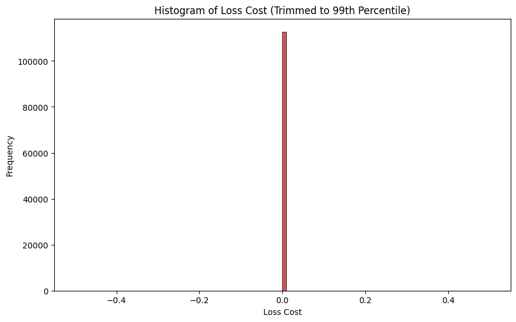

```python
# ======================================================
# Visualization of the Target Variable
# ======================================================

# Plot histogram of target variable, trimmed to 99th percentile to remove extreme tail
print("Raw histogram of target variable shows extreme spike at zero.")

# Plot histogram
plt.figure(figsize=(10, 6))
sns.histplot(train['target'][train['target'] <= train['target'].quantile(0.99)], bins=100, color='firebrick')
plt.title('Histogram of Loss Cost (Trimmed to 99th Percentile)')
plt.xlabel('Loss Cost')
plt.ylabel('Frequency')
plt.show()
```

```
Log-transformed histogram of loss cost (positive losses only) shows a long right tail.
```

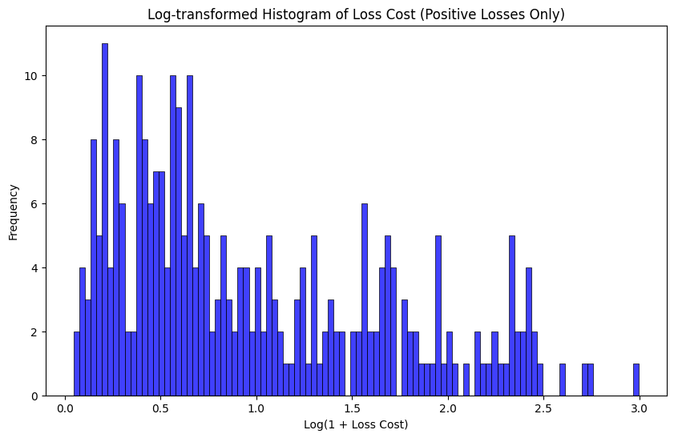

```python
# Log-transformed histogram of target variable - positive losses only
print("Log-transformed histogram of loss cost (positive losses only) shows a long right tail.")

# Determine positive losses only
positive_losses = train.loc[train['target'] > 0, 'target']

# Plot histogram
plt.figure(figsize=(10, 6))
sns.histplot(np.log1p(positive_losses), bins=100, color='blue')
plt.title('Log-transformed Histogram of Loss Cost (Positive Losses Only)')
plt.xlabel('Log(1 + Loss Cost)')
plt.ylabel('Frequency')
plt.show()
```

```
Missing Values Count for Each Column:
var16        90416
var12        88736
var14        72619
crimeVar7    29348
crimeVar2    28653
             ...
var3             0
var2             0
var1             0
target           0
id               0
Length: 302, dtype: int64

Top 20 Variables with the Most Missing Values:
var16            90416
var12            88736
var14            72619
crimeVar7        29348
crimeVar2        28653
crimeVar4        28162
crimeVar5        27640
crimeVar9        27467
crimeVar6        27467
crimeVar3        27467
crimeVar8        27467
crimeVar1        27467
var15            24689
weatherVar224     8093
weatherVar223     8093
weatherVar213     8093
weatherVar226     8093
weatherVar212     8093
weatherVar211     8093
weatherVar210     8093
dtype: int64
```

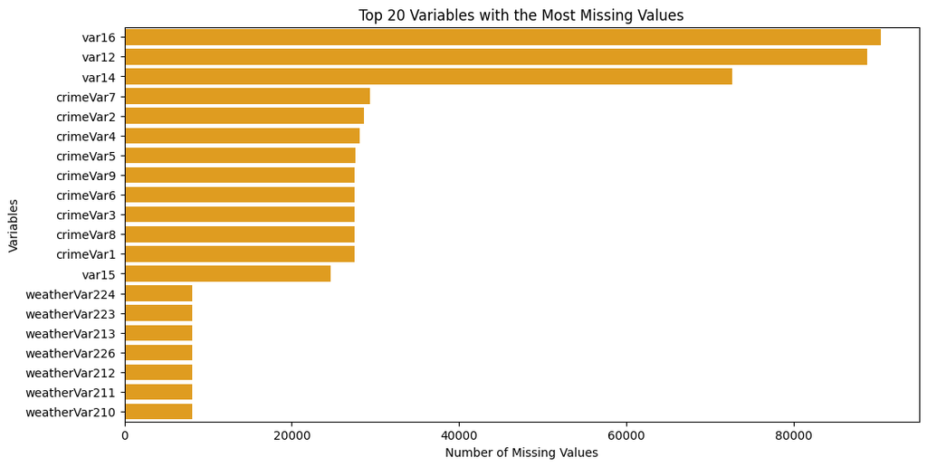

```python
# ======================================================
# Missing Data Analysis
# ======================================================

# Count number of missing values
missing_counts = train.isnull().sum().sort_values(ascending=False)
print("\nMissing Values Count for Each Column:")
print(missing_counts)

# Top 20 variables with the most missing values
print("\nTop 20 Variables with the Most Missing Values:")
print(missing_counts.head(20))

# Bar plot of missing values for top 20 variables
plt.figure(figsize=(12, 6))
sns.barplot(y=missing_counts.head(20).index, x=missing_counts.head(20).values, color='orange')
plt.title('Top 20 Variables with the Most Missing Values')
plt.ylabel('Variables')
plt.xlabel('Number of Missing Values')
plt.show()
```

```
Correlation Matrix for Numerical Columns:
                     id    target     var10     var11     var12     var13  \
id             1.000000 -0.004910  0.001718  0.000914 -0.004401  0.003019
target        -0.004910  1.000000 -0.009564 -0.002291  0.007136 -0.014378
var10          0.001718 -0.009564  1.000000  0.236153 -0.065497  0.666524
var11          0.000914 -0.002291  0.236153  1.000000  0.566343  0.126603
var12         -0.004401  0.007136 -0.065497  0.566343  1.000000 -0.313271
...                 ...       ...       ...       ...       ...       ...
weatherVar232 -0.002289  0.004573 -0.106790 -0.022230 -0.009563 -0.125590
weatherVar233 -0.000641 -0.000689  0.051272  0.045428 -0.017378  0.043839
weatherVar234 -0.000749  0.006558 -0.040275 -0.026902 -0.004615 -0.068797
weatherVar235 -0.002038  0.005290  0.031992  0.007770  0.017520 -0.004630
weatherVar236 -0.000258  0.008510  0.015604  0.002656  0.025068  0.007008

                  var14     var15     var16     var17  ...  weatherVar227  \
id            -0.001008 -0.001133 -0.003170  0.003064  ...      -0.001924
target        -0.004252  0.007537 -0.020160  0.001738  ...       0.003561
var10          0.063470 -0.120836  0.040176 -0.311835  ...       0.065549
var11          0.359582  0.014841  0.111922  0.078375  ...       0.038448
var12          0.276053  0.081992  0.184162  0.252256  ...       0.026267
...                 ...       ...       ...       ...  ...            ...
weatherVar232  0.044459  0.040876  0.037669  0.020227  ...      -0.047424
weatherVar233  0.067652  0.063676  0.015326 -0.037684  ...       0.314423
weatherVar234  0.000617 -0.024213 -0.008421  0.001149  ...      -0.055084
weatherVar235  0.002624 -0.024748  0.005383 -0.027984  ...       0.762841
weatherVar236  0.000621 -0.043124  0.044050 -0.011653  ...       0.343121

               weatherVar228  weatherVar229  weatherVar230  weatherVar231  \
id                  0.002086      -0.006479       0.000876       0.001330
target             -0.000679      -0.000698      -0.001098       0.004457
var10               0.014193       0.004360       0.040862       0.018387
var11               0.002170       0.004848       0.019624       0.000780
var12              -0.001886      -0.011036       0.017125       0.016877
...                      ...            ...            ...            ...
weatherVar232       0.006571      -0.009941       0.041428       0.015293
weatherVar233       0.000801      -0.015089       0.128515      -0.071764
weatherVar234       0.012178      -0.042540       0.058108       0.143672
weatherVar235       0.005379      -0.038903       0.119819       0.379130
weatherVar236       0.023936       0.028242       0.148375       0.825250

```

[output cut: 12 more lines]

```

               weatherVar236
id                 -0.000258
target              0.008510
var10               0.015604
var11               0.002656
var12               0.025068
...                      ...
weatherVar232       0.062509
weatherVar233      -0.051233
weatherVar234       0.207635
weatherVar235       0.597042
weatherVar236       1.000000

[292 rows x 292 columns]
```

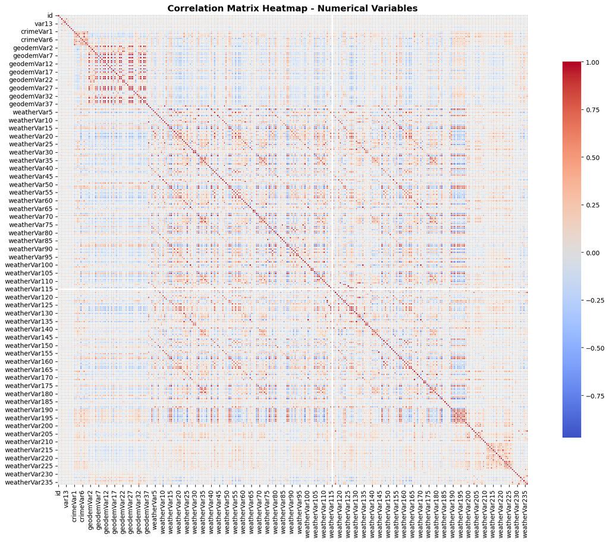

```
Correlation with Target Variable (sorted):
target           1.000000
weatherVar236    0.008510
weatherVar203    0.008314
var15            0.007537
var12            0.007136
                   ...
weatherVar47    -0.008447
var10           -0.009564
var13           -0.014378
var16           -0.020160
weatherVar115         NaN
Name: target, Length: 292, dtype: float64
```

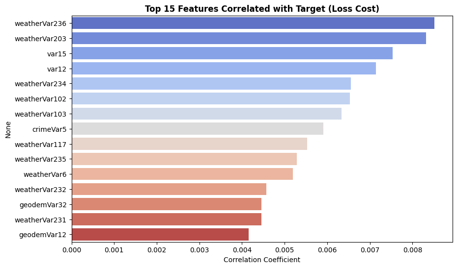

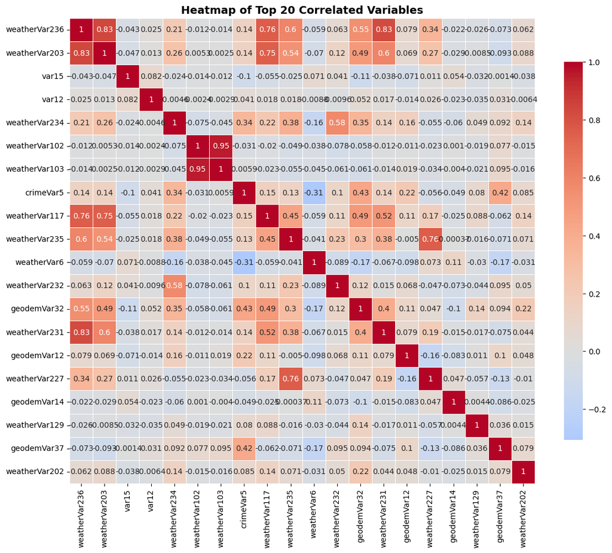

```python
# =======================================================
# Correlation Analysis
# =======================================================

# Compute correlation matrix for loss cost and numerical variables
correlation_matrix = train[numerical_cols].corr()

print("\nCorrelation Matrix for Numerical Columns:")
print(correlation_matrix)

# Visualize correlation matrix with heatmap
plt.figure(figsize=(16, 12))
sns.heatmap(correlation_matrix, annot=False, cmap='coolwarm', center=0,
            square=True, linewidths=0.5, cbar_kws={"shrink": 0.8})
plt.title('Correlation Matrix Heatmap - Numerical Variables', fontsize=14, fontweight='bold')
plt.tight_layout()
plt.show()

# Correlation with target variable
if 'target' in train.columns:
    target_corr = correlation_matrix['target'].sort_values(ascending=False)
    print("\nCorrelation with Target Variable (sorted):")
    print(target_corr)

    # Plot top 15 features correlated with target
    plt.figure(figsize=(10, 6))
    top_corr = target_corr[1:16]  # Exclude target itself
    sns.barplot(x=top_corr.values, y=top_corr.index, palette='coolwarm')
    plt.title('Top 15 Features Correlated with Target (Loss Cost)', fontsize=12, fontweight='bold')
    plt.xlabel('Correlation Coefficient')
    plt.show()

# Heatmap of top 20 correlated variables
top_corr_vars = target_corr[1:21].index  # Exclude target itself
plt.figure(figsize=(12, 10))
sns.heatmap(correlation_matrix.loc[top_corr_vars, top_corr_vars], annot=True, cmap='coolwarm', center=0,
            square=True, linewidths=0.5, cbar_kws={"shrink": 0.8})
plt.title('Heatmap of Top 20 Correlated Variables', fontsize=14, fontweight='bold')
plt.tight_layout()
plt.show()
```

The Pearson correlations between predictors and the target variable are uniformly weak. This shows that claims are rare.

The top correlated variables weather, crime and geodemographic indicators.

```
Top 3 Features Most Correlated with Target Variable:
Index(['weatherVar236', 'weatherVar203', 'var15'], dtype='str')
```

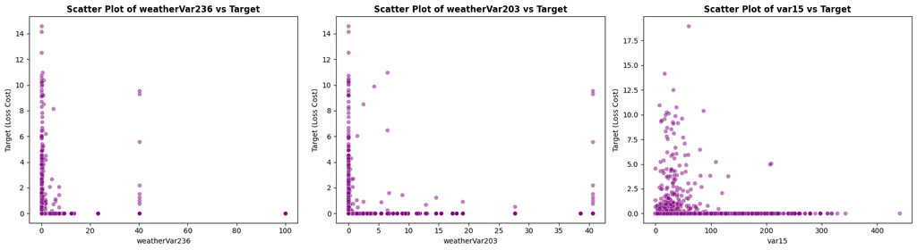

```python
# =======================================================
# Scatter Plots of Top Correlated Variables with Target
# =======================================================

# Top 3 features most correlated with target variable
top3 = target_corr[1:4].index  # Exclude target itself
print("\nTop 3 Features Most Correlated with Target Variable:")
print(top3)

# Scatter plots of top 3 features with target variable
plt.figure(figsize=(18, 5))
for i, feature in enumerate(top3):
    plt.subplot(1, 3, i+1)
    sns.scatterplot(x=train[feature], y=train['target'], alpha=0.5, color='purple')
    plt.title(f'Scatter Plot of {feature} vs Target', fontsize=12, fontweight='bold')
    plt.xlabel(feature)
    plt.ylabel('Target (Loss Cost)')
plt.tight_layout()
plt.show()
```

The scatter plots of the top 3 correlated predictors confirm that the relationships are non-linear.

## Insights on Correlation between Predictors and Target Variable (Loss Cost)

The fire-peril lost cost data has very many zeros, with nearly all observations equal to zero and a small number of extreme positive losses. The correlations between the predictors and loss cost are uniformly weak. The suggests that linear effects alone are not sufficient. This means that Tweedie GLMs and gradient boosting methods will have to be used.

# 02 - Data Preparation

## Purpose

The purpose of this notebook is to prepare the Liberty Mutual Commercial Property Fire-Peril Loss Cost dataset for statistical modelling. This means cleaning the raw data, handling missing values, transforming and scaling numeric variables, encoding categorical predictors and constructing a reproducible preprocessing pipeline that is suitable for both generalized linear models and machine-learning algorithms.

## Methodology

Data preparation involves cleaning and transforming the raw dataset to make it suitable for statistical modelling. Missing values are handled by using imputation strategies appropriate for skewed insurance data. Numeric variables are scaled and categorical variables are encoded to support both generalized linear models and machine-learning algorithms.

```python
# ======================================================
# CIND820 - Keystone Project
# Data Analysis and Visualization: Fire Peril Loss Cost (Liberty Mutual Insurance)
# Author: Debra Allen
# ======================================================

# Call Libraries
import pandas as pd
import numpy as np
import matplotlib.pyplot as plt
import seaborn as sns
import os
from pathlib import Path
```

## Data Loading

```python
# ======================================================
# Load the dataset and display basic information
# ======================================================

def find_repo_root(start_path=None, marker_files=("'git", "README.md")):
    """
    Walk up the directory to find the repository root.
    The root is identified by the presence of marker files (e.g., .git, README.md).
    """
    if start_path is None:
        start_path = Path.cwd()

    start_path = start_path.resolve()

    for parent in [start_path] + list(start_path.parents):
        for marker in marker_files:
            if (parent / marker).exists():
                return parent
    raise FileNotFoundError("Could not find repo root. Run notebook from inside the repo.")


REPO_ROOT = find_repo_root()
DATA_PATH = REPO_ROOT / "data" / "liberty_train.csv"
print("Repo Root:", REPO_ROOT)
print("Data Path:", DATA_PATH)

# Read the dataset
data = pd.read_csv(DATA_PATH, low_memory=False)

# Display the first few rows of the dataset
print("\nFirst few rows of the dataset:")
data.head()
```

```
Repo Root: C:\Users\uni_f\Downloads\LaTex\TMU-CIND820
Data Path: C:\Users\uni_f\Downloads\LaTex\TMU-CIND820\data\liberty_train.csv

First few rows of the dataset:
```

|  | id | target | var1 | var2 | var3 | var4 | var5 | var6 | var7 | var8 | ... | weatherVar227 | weatherVar228 | weatherVar229 | weatherVar230 | weatherVar231 | weatherVar232 | weatherVar233 | weatherVar234 | weatherVar235 | weatherVar236 |
| --- | --- | --- | --- | --- | --- | --- | --- | --- | --- | --- | --- | --- | --- | --- | --- | --- | --- | --- | --- | --- | --- |
| 0 | 1 | 0.0 | Z | Z | Z | N1 | Z | Z | 3 | 1 | ... | 0.170351 | 0.0 | 0.00000 | 0.000000 | 1.117353 | 1.215303 | 0.112556 | 2.355737 | 0.404655 | 0.138667 |
| 1 | 2 | 0.0 | Z | Z | Z | C1 | Z | Z | 3 | 2 | ... | 0.266173 | 0.0 | 27.50823 | 0.000000 | 3.828979 | 1.036739 | 0.033052 | 0.856632 | 0.231232 | 0.742199 |
| 2 | 3 | 0.0 | 3 | Z | 4 | J3 | B | B | 2 | 4 | ... | 0.979517 | 0.0 | 0.00000 | 0.456134 | 0.098790 | 1.076535 | 0.566352 | 0.696013 | 0.693695 | 0.070654 |
| 3 | 4 | 0.0 | 3 | Z | 4 | H1 | B | Z | 3 | 4 | ... | 0.308761 | 0.0 | 0.00000 | 4.349042 | 0.401975 | 0.340631 | 0.290147 | 0.000000 | 0.000000 | 0.090332 |
| 4 | 5 | 0.0 | Z | Z | Z | H1 | Z | Z | 2 | 4 | ... | 2.171972 | 0.0 | 0.00000 | 0.514990 | 0.516095 | 1.016120 | 1.313732 | 1.338487 | 2.948202 | 0.816485 |

5 rows × 302 columns

## Data Preparation

```python
# =======================================================
# Data Preparation for Modeling: Fire Peril Loss Cost
# =======================================================

# Import necessary libraries for data preparation
from sklearn.model_selection import train_test_split
from sklearn.preprocessing import StandardScaler, OneHotEncoder
from sklearn.compose import ColumnTransformer
from sklearn.pipeline import Pipeline
from sklearn.impute import SimpleImputer
```

```python
# Use a smaller sample for modeling to avoid memory issues
def find_repo_root(start_path=None, marker_files=("'git", "README.md")):
    """
    Walk up the directory to find the repository root.
    The root is identified by the presence of marker files (e.g., .git, README.md).
    """
    if start_path is None:
        start_path = Path.cwd()

    start_path = start_path.resolve()

    for parent in [start_path] + list(start_path.parents):
        for marker in marker_files:
            if (parent / marker).exists():
                return parent
    raise FileNotFoundError("Could not find repo root. Run notebook from inside the repo.")


REPO_ROOT = find_repo_root()
SAMPLE_PATH = REPO_ROOT / "data" / "liberty_train_subset.csv"
print("Repo Root:", REPO_ROOT)
print("Data Path:", SAMPLE_PATH)

# Load a smaller sample of the dataset for modeling
model_data = pd.read_csv(SAMPLE_PATH, low_memory=False)

# Display basic information about the dataset
model_data.info()
```

```
Repo Root: C:\Users\uni_f\Downloads\LaTex\TMU-CIND820
Data Path: C:\Users\uni_f\Downloads\LaTex\TMU-CIND820\data\liberty_train_subset.csv
<class 'pandas.DataFrame'>
RangeIndex: 113015 entries, 0 to 113014
Columns: 302 entries, id to weatherVar236
dtypes: float64(291), int64(1), str(10)
memory usage: 260.4 MB
```

```python
# Verify that all categorical variables are strings
for col in model_data.select_dtypes(include=['object']).columns:
    model_data[col] = model_data[col].astype(str)

print("\nAll categorical variables have been converted to strings.")

print("\nDataset Shape:", model_data.shape)
```

```
All categorical variables have been converted to strings.

Dataset Shape: (113015, 302)
```

```python
# Define target variable
target = 'target'

# Feature matrix and response
X = model_data.drop(columns=[target])
y = model_data[target]

# Identify categorical and numerical columns
categorical_cols = X.select_dtypes(include=['object']).columns.tolist()
numerical_cols = X.select_dtypes(include=['int64', 'float64']).columns.tolist()

print("\nCategorical Columns:", categorical_cols)
print("Numerical Columns:", numerical_cols)

# Display the number of categorical and numerical columns
print("\nNumber of Categorical Columns:", len(categorical_cols))
print("Number of Numerical Columns:", len(numerical_cols))
```

```
Categorical Columns: ['var1', 'var2', 'var3', 'var4', 'var5', 'var6', 'var7', 'var8', 'var9', 'dummy']
Numerical Columns: ['id', 'var10', 'var11', 'var12', 'var13', 'var14', 'var15', 'var16', 'var17', 'crimeVar1', 'crimeVar2', 'crimeVar3', 'crimeVar4', 'crimeVar5', 'crimeVar6', 'crimeVar7', 'crimeVar8', 'crimeVar9', 'geodemVar1', 'geodemVar2', 'geodemVar3', 'geodemVar4', 'geodemVar5', 'geodemVar6', '…

Number of Categorical Columns: 10
Number of Numerical Columns: 291
```

## Missing Values

```python
# =======================================================
# Handle Missing Values and Encode Categorical Variables
# =======================================================

# Categorical columns summary
print("\nSummary Statistics for Categorical Columns:")
print(model_data[categorical_cols].describe().T)
print("\nUnique Value Counts for Categorical Columns:")
for col in categorical_cols:
    print(f"\nUnique value counts for {col}:")
    print(model_data[col].value_counts())

# Percentage of missing values in each column
missing_values = model_data.isnull().mean() * 100
print(f"\nPercentage of Missing Values in Each Column:")
print(missing_values)

# Median for missing numerical values
num_imputer = SimpleImputer(strategy='median')
model_data[numerical_cols] = num_imputer.fit_transform(model_data[numerical_cols])

# Most frequent for missing categorical values
cat_imputer = SimpleImputer(strategy='most_frequent')
model_data[categorical_cols] = cat_imputer.fit_transform(model_data[categorical_cols])

# Verify that missing values are handled
print("\nMissing values after imputation:")
print(model_data.isnull().sum().sort_values(ascending=False).head(20))

# Combine imputation and encoding in a pipeline
numerical_pipeline = Pipeline(steps=[
    ('imputer', SimpleImputer(strategy='median')),
    ('scaler', StandardScaler())
])
categorical_pipeline = Pipeline(steps=[
    ('imputer', SimpleImputer(strategy='most_frequent')),
    ('onehot', OneHotEncoder(handle_unknown='ignore'))
])
preprocessor = ColumnTransformer(transformers=[
    ('num', numerical_pipeline, numerical_cols),
    ('cat', categorical_pipeline, categorical_cols)
],
remainder='drop')
```

```
Summary Statistics for Categorical Columns:
        count unique top    freq
var1   113015      6   Z   84432
var2   113015      4   Z  111916
var3   113015      7   Z   98718
var4   113015     43  H1   29105
var5   113015      7   Z  103970
var6   113015      4   Z  106238
var7   113015      9   3   30413
var8   113015      7   2   30450
var9   113015      3   A   73564
dummy  113015      2   A   82166

Unique Value Counts for Categorical Columns:

Unique value counts for var1:
var1
Z    84432
3    14384
2     8324
4     5344
1      518
5       13
Name: count, dtype: int64

Unique value counts for var2:
var2
Z    111916
B       610
C       415
A        74
Name: count, dtype: int64

Unique value counts for var3:
var3
Z    98718
3     5807
4     5035
2     1594
6      843
```

[output cut: 128 more lines]

```
var5      0
var6      0
var7      0
var8      0
var9      0
var10     0
var11     0
var12     0
var13     0
var14     0
var15     0
var16     0
var17     0
dummy     0
dtype: int64
```

## Train-Test Split

```python
# =======================================================
# Train-Test Split
# =======================================================

# Split the data into training and testing sets
X_train, X_test, y_train, y_test = train_test_split(X, y, test_size=0.2, random_state=42)

print("\nTraining observations:", X_train.shape[0])
print("Testing observations:", X_test.shape[0])
```

```
Training observations: 90412
Testing observations: 22603
```

## Data Preprocessing

```python
# =======================================================
# Data Preprocessing Pipeline
# =======================================================

# Fit prepocessing pipeline on training data and transform both training and testing data
X_train_prepared = preprocessor.fit_transform(X_train)
X_test_prepared = preprocessor.transform(X_test)

print("\nData preprocessing pipeline has been applied to training and testing data.")

print("\nShape of preprocessed training data:", X_train_prepared.shape)
print("Shape of preprocessed testing data:", X_test_prepared.shape)
```

```
Data preprocessing pipeline has been applied to training and testing data.

Shape of preprocessed training data: (90412, 383)
Shape of preprocessed testing data: (22603, 383)
```

```python
# =======================================================
# Subsample for Modeling Efficiency
# =======================================================

# To further reduce memory usage, take a random subsample of the preprocessed training data for modeling.
sample_size = 5000  # Adjust this number based on memory constraints

if X_train_prepared.shape[0] > sample_size:
    idx = np.random.choice(X_train_prepared.shape[0], sample_size, replace=False)
    X_train_sample = X_train_prepared[idx]
    y_train_sample = y_train.iloc[idx]
    print(f"\nSubsampled {sample_size} observations for modeling.")
else:
    X_train_sample = X_train_prepared
    y_train_sample = y_train
    print("\nTraining data is small enough to use without subsampling.")
```

```
Subsampled 5000 observations for modeling.
```

## Data Preparation Summary

Data preparation involved converting categorical variables to string format, changing missing numeric values with the median and categorical values with the modal categories and standardizing the numeric predictors. Categorical values were one-hot encoded to support machine-learning models. A consistent preprocessing pipeline was applied to training and test data to prevent data leakage. Since there were a large number of variables, a smaller sample was taken so that models could be developed and tested efficiently.

# 03 - Tweedie GLM Model

## Purpose

The purpose of this notebook is to develop and evaluate a Tweedie generalized linear model for modelling commercial property fire-peril loss cost. The Tweedie distribution with a log link is used to accommodate the highly zero-inflated and right-skewed nature of the insurance loss data. The model serves as a traditional actuarial baseline against which more flexible machine-learning approaches are compared.

## Methodology

A Tweedie generalized linear model with a log link is fitted to model the fire-peril loss cost. The Tweedie distribution is selected because of its ability to accommodate a point mass at zero and a continuous positive tail. Model performance is evaluated using RMSE, MAE and R^2 on a test set.

```python
# ======================================================
# CIND820 - Keystone Project
# Tweedie GLM Model: Fire Peril Loss Cost (Liberty Mutual Insurance)
# Author: Debra Allen
# ======================================================

# Call Libraries
import pandas as pd
import numpy as np
import matplotlib.pyplot as plt
import seaborn as sns
import os
from pathlib import Path
```

## Data Loading

```python
# =======================================================
# Data Preparation for Modeling: Fire Peril Loss Cost
# =======================================================

# Import necessary libraries for data preparation
from sklearn.model_selection import train_test_split
from sklearn.preprocessing import StandardScaler, OneHotEncoder
from sklearn.compose import ColumnTransformer
from sklearn.pipeline import Pipeline
from sklearn.impute import SimpleImputer
from sklearn.linear_model import TweedieRegressor
from sklearn.model_selection import KFold
from sklearn.metrics import mean_squared_error, mean_absolute_error, r2_score
```

```python
# ======================================================
# Load the dataset and display basic information
# ======================================================

# Use a smaller sample for modeling to avoid memory issues
def find_repo_root(start_path=None, marker_files=("'git", "README.md")):
    """
    Walk up the directory to find the repository root.
    The root is identified by the presence of marker files (e.g., .git, README.md).
    """
    if start_path is None:
        start_path = Path.cwd()

    start_path = start_path.resolve()

    for parent in [start_path] + list(start_path.parents):
        for marker in marker_files:
            if (parent / marker).exists():
                return parent
    raise FileNotFoundError("Could not find repo root. Run notebook from inside the repo.")

REPO_ROOT = find_repo_root()
SAMPLE_PATH = REPO_ROOT / "data" / "liberty_train_subset.csv"
print("Repo Root:", REPO_ROOT)
print("Data Path:", SAMPLE_PATH)

# Load a smaller sample of the dataset for modeling
model_data = pd.read_csv(SAMPLE_PATH, low_memory=False)

# Display basic information about the dataset
model_data.info()
```

```
Repo Root: C:\Users\uni_f\Downloads\LaTex\TMU-CIND820
Data Path: C:\Users\uni_f\Downloads\LaTex\TMU-CIND820\data\liberty_train_subset.csv
<class 'pandas.DataFrame'>
RangeIndex: 113015 entries, 0 to 113014
Columns: 302 entries, id to weatherVar236
dtypes: float64(291), int64(1), str(10)
memory usage: 260.4 MB
```

## Data Preparation

```python
# ======================================================
# Prepare the dataset for modeling
# ======================================================

# Convert categorical variables to string type (if any)
for col in model_data.select_dtypes(include=["object"]).columns:
    model_data[col] = model_data[col].astype(str)

# Define the target variable and predictor variables
target = "target"
X = model_data.drop(columns=[target])
y = model_data[target]
```

```python
# ======================================================
# Identify Variable Types
# ======================================================

# Identify categorical and numerical variables
categorical_vars = X.select_dtypes(include=["object"]).columns.tolist()
numerical_vars = X.select_dtypes(include=["int64", "float64"]).columns.tolist()

# Display variable types
print("Categorical Variables:", categorical_vars)
print("Numerical Variables:", numerical_vars)

# Display number of numerical and categorical variables
print("\nNumber of Categorical Variables:", len(categorical_vars))
print("Number of Numerical Variables:", len(numerical_vars))
```

```
Categorical Variables: ['var1', 'var2', 'var3', 'var4', 'var5', 'var6', 'var7', 'var8', 'var9', 'dummy']
Numerical Variables: ['id', 'var10', 'var11', 'var12', 'var13', 'var14', 'var15', 'var16', 'var17', 'crimeVar1', 'crimeVar2', 'crimeVar3', 'crimeVar4', 'crimeVar5', 'crimeVar6', 'crimeVar7', 'crimeVar8', 'crimeVar9', 'geodemVar1', 'geodemVar2', 'geodemVar3', 'geodemVar4', 'geodemVar5', 'geodemVar6',…

Number of Categorical Variables: 10
Number of Numerical Variables: 291
```

## Preprocessing the Data

```python
# ======================================================
# Preprocess the dataset
# ======================================================

# Numerical pipeline: impute missing values with median and scale features
numerical_pipeline = Pipeline(steps=[
    ('imputer', SimpleImputer(strategy='median')),
    ('scaler', StandardScaler())
])

# Categorical pipeline: impute missing values with most frequent and one-hot encode
categorical_pipeline = Pipeline(steps=[
    ('imputer', SimpleImputer(strategy='most_frequent')),
    ('onehot', OneHotEncoder(handle_unknown='ignore', sparse_output=False))
])

# Combine numerical and categorical pipelines into a ColumnTransformer
preprocessor = ColumnTransformer(transformers=[
    ('num', numerical_pipeline, numerical_vars),
    ('cat', categorical_pipeline, categorical_vars)
],
remainder='drop',
n_jobs=-1
)
```

```python
# =======================================================
# Train-Test Split
# =======================================================

# Split the data into training and testing sets
X_train, X_test, y_train, y_test = train_test_split(X, y, test_size=0.2, random_state=42)

print("\nTraining observations:", X_train.shape[0])
print("Testing observations:", X_test.shape[0])
```

```
Training observations: 90412
Testing observations: 22603
```

## Tweedie GLM Model

```python
# ======================================================
# Tweedie GLM Model
# ======================================================

tweedie_glm = TweedieRegressor(
    power=1.5,  # Tweedie distribution with power between 1 and 2 for insurance claims
    alpha=0.1,  # Regularization strength
    link='log',
    max_iter=1000
)
```

```python
# ======================================================
# Full Modeling Pipeline
# ======================================================

model_pipeline = Pipeline(steps=[
    ('preprocessor', preprocessor),
    ('model', tweedie_glm)
])
```

## Model Training

```python
# ======================================================
# Model Training
# ======================================================

model_pipeline.fit(X_train, y_train)

print("Tweedie GLM fitted successfully.")
```

```
Tweedie GLM fitted successfully.
```

## Cross-Validation

```python
# ======================================================
# Cross-Validation for Tweedie GLM
# ======================================================

# Define K-Fold cross-validation
def cross_validate_rmse(model_pipeline, X, y, n_splits=5):
    kf = KFold(n_splits=n_splits, shuffle=True, random_state=42)
    rmse_scores = []

    for train_index, val_index in kf.split(X):
        X_train_cv, X_val_cv = X.iloc[train_index], X.iloc[val_index]
        y_train_cv, y_val_cv = y.iloc[train_index], y.iloc[val_index]

        model_pipeline.fit(X_train_cv, y_train_cv)
        y_pred_cv = model_pipeline.predict(X_val_cv)

        rmse = np.sqrt(mean_squared_error(y_val_cv, y_pred_cv))
        rmse_scores.append(rmse)

    return np.mean(rmse_scores), np.std(rmse_scores)

# Perform cross-validation and print results
cv_mean_glm, cv_std_glm = cross_validate_rmse(
    model_pipeline,
    X_train,
    y_train,
    n_splits=5
)

print(f"Cross-Validation Results for Tweedie GLM:")
print(f"Mean RMSE: {cv_mean_glm:.4f}", cv_mean_glm)
print(f"Standard Deviation: {cv_std_glm:.4f}", cv_std_glm)
```

```
Cross-Validation Results for Tweedie GLM:
Mean RMSE: 0.2039 0.20385202727942095
Standard Deviation: 0.0334 0.03342007233954466
```

## Model Evaluation

```python
# ======================================================
# Model Evaluation
# ======================================================

# Predict on the test set
y_pred = model_pipeline.predict(X_test)

# Evaluate model performance
mse = mean_squared_error(y_test, y_pred)  # RMSE
mae = mean_absolute_error(y_test, y_pred)
r2 = r2_score(y_test, y_pred)

# Display evaluation results
print("\nTweedie GLM Performance (Test Dataset):")
print("---------------------------------------")
print(f"Mean Squared Error (MSE): {mse:.4f}")
print(f"Mean Absolute Error (MAE): {mae:.4f}")
print(f"R-squared (R2): {r2:.4f}")
```

```
Tweedie GLM Performance (Test Dataset):
---------------------------------------
Mean Squared Error (MSE): 0.0626
Mean Absolute Error (MAE): 0.0144
R-squared (R2): -0.0001
```

## Coefficients Interpretation

```python
# ======================================================
# Coefficients Interpretation
# ======================================================

# Extract model coefficients after preprocessing
var_names_num = numerical_vars
var_names_cat = model_pipeline.named_steps['preprocessor'] \
    .named_transformers_["cat"] \
    .named_steps["onehot"] \
    .get_feature_names_out(categorical_vars)

feature_names = np.concatenate([var_names_num, var_names_cat])

# Extract coefficients from the model
coefficients = model_pipeline.named_steps['model'].coef_

# Create a DataFrame for coefficients
coef_table = pd.DataFrame({
    'Feature': feature_names,
    'Coefficient': coefficients
}).sort_values(by='Coefficient', key=abs, ascending=False)

coef_table.head(20)  # Display top 20 features by absolute coefficient value
```

|  | Feature | Coefficient |
| --- | --- | --- |
| 4 | var13 | -0.185218 |
| 336 | var4_M1 | 0.103273 |
| 1 | var10 | -0.099791 |
| 268 | weatherVar214 | 0.096316 |
| 371 | var8_1 | 0.094750 |
| 7 | var16 | -0.084189 |
| 156 | weatherVar102 | 0.081940 |
| 274 | weatherVar220 | -0.072615 |
| 157 | weatherVar103 | 0.072076 |
| 54 | geodemVar37 | 0.069565 |
| 60 | weatherVar6 | 0.066093 |
| 153 | weatherVar99 | 0.060396 |
| 11 | crimeVar3 | 0.057265 |
| 41 | geodemVar24 | 0.056894 |
| 56 | weatherVar2 | -0.055714 |
| 26 | geodemVar9 | -0.052223 |
| 313 | var4_D3 | -0.051793 |
| 47 | geodemVar30 | 0.049314 |
| 3 | var12 | 0.049043 |
| 278 | weatherVar224 | -0.048822 |

## Tweedie GLM Summary

A Tweedie generalized linear model with a log link was fitted to model fire-peril loss cost. The Tweedie distribution is well-suited to insurance data because it can handle a large amount of zeros and a continuous positive tail. The model evaluation on a hold-out test shows limited explanatory power, reflecting the extreme sparsity and weak linear relationships in the data. Nevertheless, the GLM provides a stable interpretable baseline against which is more flexible machine-learning methods can be compared.

# 04 - Gradient Boosting Model

## Purpose

The purpose of this notebook is to develop a gradient boosting regression model for predicting commercial property fire-peril loss cost. Gradient boosting is used to capture non-linear relationships and interactions among predictors that may not be well represented by generalized linear models. Model performance is evaluated using the same metrics and data partition as Tweedie GLM to allow for direct comparison.

## Methodology

A gradient boosting regression model is developed to capture non-linear relationships and interactions among predictors. The model is trained using a consistent preprocessing pipeline and evaluated on the same test as the Tweedie GLM to allow for direct comparison.

```python
# ======================================================
# CIND820 - Keystone Project
# Gradient Boosting Model: Fire Peril Loss Cost (Liberty Mutual Insurance)
# Author: Debra Allen
# ======================================================

# Call Libraries
import pandas as pd
import numpy as np
import matplotlib.pyplot as plt
import seaborn as sns
import os
from pathlib import Path
```

## Data Loading

```python
# =======================================================
# Data Preparation for Modeling: Fire Peril Loss Cost
# =======================================================

# Import necessary libraries for data preparation
from sklearn.model_selection import train_test_split
from sklearn.preprocessing import StandardScaler, OneHotEncoder
from sklearn.compose import ColumnTransformer
from sklearn.pipeline import Pipeline
from sklearn.impute import SimpleImputer
from sklearn.ensemble import GradientBoostingRegressor
from sklearn.model_selection import KFold
from sklearn.metrics import mean_squared_error, mean_absolute_error, r2_score
```

```python
# ======================================================
# Load the dataset and display basic information
# ======================================================

# Use a smaller sample for modeling to avoid memory issues
def find_repo_root(start_path=None, marker_files=("'git", "README.md")):
    """
    Walk up the directory to find the repository root.
    The root is identified by the presence of marker files (e.g., .git, README.md).
    """
    if start_path is None:
        start_path = Path.cwd()

    start_path = start_path.resolve()

    for parent in [start_path] + list(start_path.parents):
        for marker in marker_files:
            if (parent / marker).exists():
                return parent
    raise FileNotFoundError("Could not find repo root. Run notebook from inside the repo.")

REPO_ROOT = find_repo_root()
SAMPLE_PATH = REPO_ROOT / "data" / "liberty_train_subset.csv"
print("Repo Root:", REPO_ROOT)
print("Data Path:", SAMPLE_PATH)

# Load a smaller sample of the dataset for modeling
model_data = pd.read_csv(SAMPLE_PATH, low_memory=False)

# Display basic information about the dataset
model_data.info()
```

```
Repo Root: C:\Users\uni_f\Downloads\LaTex\TMU-CIND820
Data Path: C:\Users\uni_f\Downloads\LaTex\TMU-CIND820\data\liberty_train_subset.csv
<class 'pandas.DataFrame'>
RangeIndex: 113015 entries, 0 to 113014
Columns: 302 entries, id to weatherVar236
dtypes: float64(291), int64(1), str(10)
memory usage: 260.4 MB
```

## Data Preparation

```python
# ======================================================
# Prepare the dataset for modeling
# ======================================================

# Convert categorical variables to string type (if any)
for col in model_data.select_dtypes(include=["object"]).columns:
    model_data[col] = model_data[col].astype(str)

# Define the target variable and predictor variables
target = "target"
X = model_data.drop(columns=[target])
y = model_data[target]
```

```python
# ======================================================
# Identify Variable Types
# ======================================================

# Identify categorical and numerical variables
categorical_vars = X.select_dtypes(include=["object"]).columns.tolist()
numerical_vars = X.select_dtypes(include=["int64", "float64"]).columns.tolist()

# Display variable types
print("Categorical Variables:", categorical_vars)
print("Numerical Variables:", numerical_vars)

# Display number of numerical and categorical variables
print("\nNumber of Categorical Variables:", len(categorical_vars))
print("Number of Numerical Variables:", len(numerical_vars))
```

```
Categorical Variables: ['var1', 'var2', 'var3', 'var4', 'var5', 'var6', 'var7', 'var8', 'var9', 'dummy']
Numerical Variables: ['id', 'var10', 'var11', 'var12', 'var13', 'var14', 'var15', 'var16', 'var17', 'crimeVar1', 'crimeVar2', 'crimeVar3', 'crimeVar4', 'crimeVar5', 'crimeVar6', 'crimeVar7', 'crimeVar8', 'crimeVar9', 'geodemVar1', 'geodemVar2', 'geodemVar3', 'geodemVar4', 'geodemVar5', 'geodemVar6',…

Number of Categorical Variables: 10
Number of Numerical Variables: 291
```

## Preprocessing the Data

```python
# ======================================================
# Preprocess the dataset
# ======================================================

# Numerical pipeline: impute missing values with median
numerical_pipeline = Pipeline(steps=[
    ('imputer', SimpleImputer(strategy='median'))
])

# Categorical pipeline: impute missing values with most frequent and one-hot encode
categorical_pipeline = Pipeline(steps=[
    ('imputer', SimpleImputer(strategy='most_frequent')),
    ('onehot', OneHotEncoder(handle_unknown='ignore', sparse_output=False))
])

# Combine numerical and categorical pipelines into a ColumnTransformer
preprocessor = ColumnTransformer(transformers=[
    ('num', numerical_pipeline, numerical_vars),
    ('cat', categorical_pipeline, categorical_vars)
],
remainder='drop',
n_jobs=-1
)
```

```python
# =======================================================
# Train-Test Split
# =======================================================

# Split the data into training and testing sets
X_train, X_test, y_train, y_test = train_test_split(X, y, test_size=0.2, random_state=42)

print("\nTraining observations:", X_train.shape[0])
print("Testing observations:", X_test.shape[0])
```

```
Training observations: 90412
Testing observations: 22603
```

## Gradient Boosting Model

```python
# ======================================================
# Gradient Boosting Model Specification
# ======================================================

gradient_boosting_model = GradientBoostingRegressor(
    n_estimators=200,  # Number of boosting stages
    learning_rate=0.05,  # Learning rate
    max_depth=3,  # Maximum depth of the individual regression estimators
    subsample=0.8,  # Subsample ratio of the training instances
    random_state=42
)
```

```python
# ======================================================
# Full Modeling Pipeline
# ======================================================

gbr_pipeline = Pipeline(steps=[
    ('preprocessor', preprocessor),
    ('model', gradient_boosting_model)
])
```

## Model Training

```python
# ======================================================
# Model Training
# ======================================================

gbr_pipeline.fit(X_train, y_train)

print("Gradient Boosting Model fitted successfully.")
```

```
Gradient Boosting Model fitted successfully.
```

## Cross-Validation

```python
# ======================================================
# Cross-Validation for Gradient Boosting
# ======================================================

# Define K-Fold cross-validation
def cross_validate_rmse(gbr_pipeline, X, y, n_splits=5):
    kf = KFold(n_splits=n_splits, shuffle=True, random_state=42)
    rmse_scores = []

    for train_index, val_index in kf.split(X):
        X_train_cv, X_val_cv = X.iloc[train_index], X.iloc[val_index]
        y_train_cv, y_val_cv = y.iloc[train_index], y.iloc[val_index]

        gbr_pipeline.fit(X_train_cv, y_train_cv)
        y_pred_cv = gbr_pipeline.predict(X_val_cv)

        rmse = np.sqrt(mean_squared_error(y_val_cv, y_pred_cv))
        rmse_scores.append(rmse)

    return np.mean(rmse_scores), np.std(rmse_scores)

# Perform cross-validation and print results
cv_mean_gbm, cv_std_gbm = cross_validate_rmse(
    gbr_pipeline,
    X_train,
    y_train,
    n_splits=5
)

print(f"Cross-Validation Results for Gradient Boosting:")
print(f"Mean RMSE: {cv_mean_gbm:.4f}", cv_mean_gbm)
print(f"Standard Deviation: {cv_std_gbm:.4f}", cv_std_gbm)
```

```
Cross-Validation Results for Gradient Boosting:
Mean RMSE: 0.2107 0.21068362681916977
Standard Deviation: 0.0281 0.0281393031754367
```

## Model Evaluation

```python
# ======================================================
# Model Evaluation
# ======================================================

# Predict on the test set
y_pred = gbr_pipeline.predict(X_test)

# Evaluate model performance
mse = mean_squared_error(y_test, y_pred)  # RMSE
mae = mean_absolute_error(y_test, y_pred)
r2 = r2_score(y_test, y_pred)

# Display evaluation results
print("\nGradient Boosting Performance (Test Dataset):")
print("-------------------------------------------------")
print(f"Mean Squared Error (MSE): {mse:.4f}")
print(f"Mean Absolute Error (MAE): {mae:.4f}")
print(f"R-squared (R2): {r2:.4f}")
```

```
Gradient Boosting Performance (Test Dataset):
-------------------------------------------------
Mean Squared Error (MSE): 0.0644
Mean Absolute Error (MAE): 0.0155
R-squared (R2): -0.0289
```

## Gradient Boosting Model Interpretation

```python
# ======================================================
# Gradient Boosting Model Interpretation
# ======================================================

# Extract model coefficients after preprocessing
var_names_num = numerical_vars
var_names_cat = gbr_pipeline.named_steps['preprocessor'] \
    .named_transformers_["cat"] \
    .named_steps["onehot"] \
    .get_feature_names_out(categorical_vars)

feature_names = np.concatenate([var_names_num, var_names_cat])

# Extract feature importances from the model
importances = gbr_pipeline.named_steps['model'].feature_importances_

# Create a DataFrame for coefficients
importance_table = pd.DataFrame({
    'Feature': feature_names,
    'Importance': importances
}).sort_values(by='Importance', ascending=False)

importance_table.head(20)  # Display top 20 features by importance value
```

|  | Feature | Importance |
| --- | --- | --- |
| 349 | var4_S1 | 0.096249 |
| 4 | var13 | 0.091328 |
| 348 | var4_R8 | 0.055911 |
| 6 | var15 | 0.047300 |
| 2 | var11 | 0.038204 |
| 0 | id | 0.037538 |
| 336 | var4_M1 | 0.027664 |
| 109 | weatherVar55 | 0.025969 |
| 367 | var7_6 | 0.021304 |
| 366 | var7_5 | 0.020447 |
| 149 | weatherVar95 | 0.019732 |
| 293 | var1_3 | 0.018808 |
| 8 | var17 | 0.018757 |
| 347 | var4_R7 | 0.017999 |
| 84 | weatherVar30 | 0.017643 |
| 156 | weatherVar102 | 0.016442 |
| 1 | var10 | 0.016293 |
| 48 | geodemVar31 | 0.014331 |
| 371 | var8_1 | 0.013271 |
| 324 | var4_H1 | 0.012860 |

## Gradient Boosting Summary

# 05 - Model Comparison: Tweedie GLM vs Gradient Boosting

## Purpose

The purpose of this notebook is to compare the predictive performance of the Tweedie GLM model and the Gradient Boosting model. Using a consistent preprocessing pipeline and evaluation framework, the models are assessed using standard regression metrics to highlight differences in accuracy, interpretability and suitability for commercial property fire-peril loss cost modelling.

## Methodology

This notebook compares a Tweedie GLM and a Gradient Boosting regression model for predicting commercial property fire-peril loss cost. Both models are evaluated using the same training-test split, preprocessing pipeline and evaluation metrics to ensure a fair comparison.

```python
# ======================================================
# CIND820 - Keystone Project
# Model Comparison: Fire Peril Loss Cost (Liberty Mutual Insurance)
# Author: Debra Allen
# ======================================================

# Call Libraries
import pandas as pd
import numpy as np
import matplotlib.pyplot as plt
import seaborn as sns
import os
from pathlib import Path
```

```python
# =======================================================
# Data Preparation for Modeling: Fire Peril Loss Cost
# =======================================================

# Import necessary libraries for data preparation
from sklearn.model_selection import train_test_split
from sklearn.preprocessing import StandardScaler, OneHotEncoder
from sklearn.compose import ColumnTransformer
from sklearn.pipeline import Pipeline
from sklearn.impute import SimpleImputer
from sklearn.linear_model import TweedieRegressor
from sklearn.ensemble import GradientBoostingRegressor
from sklearn.metrics import mean_squared_error, mean_absolute_error, r2_score
```

## Data Loading

```python
# ======================================================
# Load the dataset and display basic information
# ======================================================

# Use a smaller sample for modeling to avoid memory issues
def find_repo_root(start_path=None, marker_files=("'git", "README.md")):
    """
    Walk up the directory to find the repository root.
    The root is identified by the presence of marker files (e.g., .git, README.md).
    """
    if start_path is None:
        start_path = Path.cwd()

    start_path = start_path.resolve()

    for parent in [start_path] + list(start_path.parents):
        for marker in marker_files:
            if (parent / marker).exists():
                return parent
    raise FileNotFoundError("Could not find repo root. Run notebook from inside the repo.")

REPO_ROOT = find_repo_root()
SAMPLE_PATH = REPO_ROOT / "data" / "liberty_train_subset.csv"
print("Repo Root:", REPO_ROOT)
print("Data Path:", SAMPLE_PATH)

# Load a smaller sample of the dataset for modeling
model_data = pd.read_csv(SAMPLE_PATH, low_memory=False)

# Display basic information about the dataset
model_data.info()
```

```
Repo Root: C:\Users\uni_f\Downloads\LaTex\TMU-CIND820
Data Path: C:\Users\uni_f\Downloads\LaTex\TMU-CIND820\data\liberty_train_subset.csv
<class 'pandas.DataFrame'>
RangeIndex: 113015 entries, 0 to 113014
Columns: 302 entries, id to weatherVar236
dtypes: float64(291), int64(1), str(10)
memory usage: 260.4 MB
```

## Data Preparation

```python
# ======================================================
# Prepare the dataset for modeling
# ======================================================

# Convert categorical variables to string type (if any)
for col in model_data.select_dtypes(include=["object"]).columns:
    model_data[col] = model_data[col].astype(str)

# Define the target variable and predictor variables
target = "target"
X = model_data.drop(columns=[target])
y = model_data[target]
```

```python
# ======================================================
# Identify Variable Types
# ======================================================

# Identify categorical and numerical variables
categorical_vars = X.select_dtypes(include=["object"]).columns.tolist()
numerical_vars = X.select_dtypes(include=["int64", "float64"]).columns.tolist()

# Display variable types
print("Categorical Variables:", categorical_vars)
print("Numerical Variables:", numerical_vars)

# Display number of numerical and categorical variables
print("\nNumber of Categorical Variables:", len(categorical_vars))
print("Number of Numerical Variables:", len(numerical_vars))
```

```
Categorical Variables: ['var1', 'var2', 'var3', 'var4', 'var5', 'var6', 'var7', 'var8', 'var9', 'dummy']
Numerical Variables: ['id', 'var10', 'var11', 'var12', 'var13', 'var14', 'var15', 'var16', 'var17', 'crimeVar1', 'crimeVar2', 'crimeVar3', 'crimeVar4', 'crimeVar5', 'crimeVar6', 'crimeVar7', 'crimeVar8', 'crimeVar9', 'geodemVar1', 'geodemVar2', 'geodemVar3', 'geodemVar4', 'geodemVar5', 'geodemVar6',…

Number of Categorical Variables: 10
Number of Numerical Variables: 291
```

## Preprocessing the Data

```python
# ======================================================
# Preprocess the dataset
# ======================================================

# Numerical pipeline: impute missing values with median and standardize
numerical_pipeline = Pipeline(steps=[
    ('imputer', SimpleImputer(strategy='median')),
    ('scaler', StandardScaler())
])

# Categorical pipeline: impute missing values with most frequent and one-hot encode
categorical_pipeline = Pipeline(steps=[
    ('imputer', SimpleImputer(strategy='most_frequent')),
    ('onehot', OneHotEncoder(handle_unknown='ignore', sparse_output=False))
])

# Combine numerical and categorical pipelines into a ColumnTransformer
preprocessor = ColumnTransformer(transformers=[
    ('num', numerical_pipeline, numerical_vars),
    ('cat', categorical_pipeline, categorical_vars)
],
remainder='drop',
n_jobs=-1
)
```

```python
# =======================================================
# Train-Test Split
# =======================================================

# Split the data into training and testing sets
X_train, X_test, y_train, y_test = train_test_split(X, y, test_size=0.2, random_state=42)

print("\nTraining observations:", X_train.shape[0])
print("Testing observations:", X_test.shape[0])
```

```
Training observations: 90412
Testing observations: 22603
```

## Define Models

```python
# ======================================================
# Define Models
# ======================================================

# Define the Tweedie GLM model
glm_model = TweedieRegressor(
    power=1.5,  # Tweedie distribution with power between 1 and 2 for insurance claims
    alpha=0.1,  # Regularization strength
    link='log',
    max_iter=1000
)

# Define the Gradient Boosting Regressor model
gbm_model = GradientBoostingRegressor(
    n_estimators=200,
    learning_rate=0.05,
    max_depth=3,
    subsample=0.8,
    random_state=42
)
```

## Create Pipelines for Both Models

```python
# ======================================================
# Build Pipelines for Both Models
# ======================================================

# Pipeline for Tweedie GLM model
glm_pipeline = Pipeline(steps=[
    ('preprocessor', preprocessor),
    ('model', glm_model)
])

# Pipeline for Gradient Boosting Regressor model
gbm_pipeline = Pipeline(steps=[
    ('preprocessor', preprocessor),
    ('model', gbm_model)
])
```

## Fit Models to Training Data

```python
# ======================================================
# Fit the models on the training data
# ======================================================

glm_pipeline.fit(X_train, y_train)
gbm_pipeline.fit(X_train, y_train)

print("Tweedie GLM fitted successfully.")
print("Gradient Boosting Model fitted successfully.")
```

```
Tweedie GLM fitted successfully.
Gradient Boosting Model fitted successfully.
```

## Model Evaluation

```python
# ======================================================
# Evaluate the models on the testing data
# ======================================================

# Predictions
def predict_and_evaluate(model, X_test, y_test):
    y_pred = model.predict(X_test)
    return{
        'RMSE': mean_squared_error(y_test, y_pred),
        'MAE': mean_absolute_error(y_test, y_pred),
        'R2': r2_score(y_test, y_pred)
    }

glm_metrics = predict_and_evaluate(glm_pipeline, X_test, y_test)
gbm_metrics = predict_and_evaluate(gbm_pipeline, X_test, y_test)

y_pred_glm = glm_pipeline.predict(X_test)
y_pred_gbm = gbm_pipeline.predict(X_test)
```

## Weighted GINI

```python
# ======================================================
# Calculate Weighted GINI
# ======================================================

def weighted_gini(y_true, y_pred, sample_weight=None):
    """ Compute the weighted GINI coefficient for regression predictions.
    """
    if sample_weight is None:
        sample_weight = np.ones_like(y_true)

    # Sort by predicted values
    sorted_indices = np.argsort(y_pred)
    y_true = y_true[sorted_indices]
    y_pred = y_pred[sorted_indices]
    sample_weight = sample_weight[sorted_indices]

    # Cumulative sums
    cum_weight = np.cumsum(sample_weight)
    cum_loss = np.cumsum(y_true * sample_weight)

    # Total sums
    gini = np.sum(
        cum_loss[:-1] * sample_weight[1:] -
        cum_loss[1:] * sample_weight[:-1]
    )
    return gini / (cum_loss[-1] * cum_weight[-1])

# Calculate weighted GINI for both models
gini_glm = weighted_gini(y_test.values, y_pred_glm)
gini_gbm = weighted_gini(y_test.values, y_pred_gbm)

print("Tweedie GLM Gini: ", f"{gini_glm:.9f}", gini_glm)
print("Gradient Boosting Gini: ", f"{gini_gbm:.9f}", gini_gbm)
```

```
Tweedie GLM Gini:  -0.000044242 -4.424191479007212e-05
Gradient Boosting Gini:  -0.000044242 -4.424191479007211e-05
```

## Model Comparison

```python
# ======================================================
# Create Comparison Table of Model Performance
# ======================================================

results = pd.DataFrame.from_dict(
    {
        'GLM': glm_metrics,
        'GBM': gbm_metrics
    },
    orient='index'
)

print("\nModel Performance Comparison:")
print(results)

# Create a more visually appealing comparison table
comparison_table = pd.DataFrame.from_dict(
    {
        'Tweedie GLM': glm_metrics,
        'Gradient Boosting': gbm_metrics
    },
    orient='index'
)

print("\nModel Performance Comparison:")
comparison_table
```

```
Model Performance Comparison:
         RMSE       MAE        R2
GLM  0.062604  0.014360 -0.000149
GBM  0.064260  0.015564 -0.026604

Model Performance Comparison:
```

[output not shown]

## Model Comparison Visualization

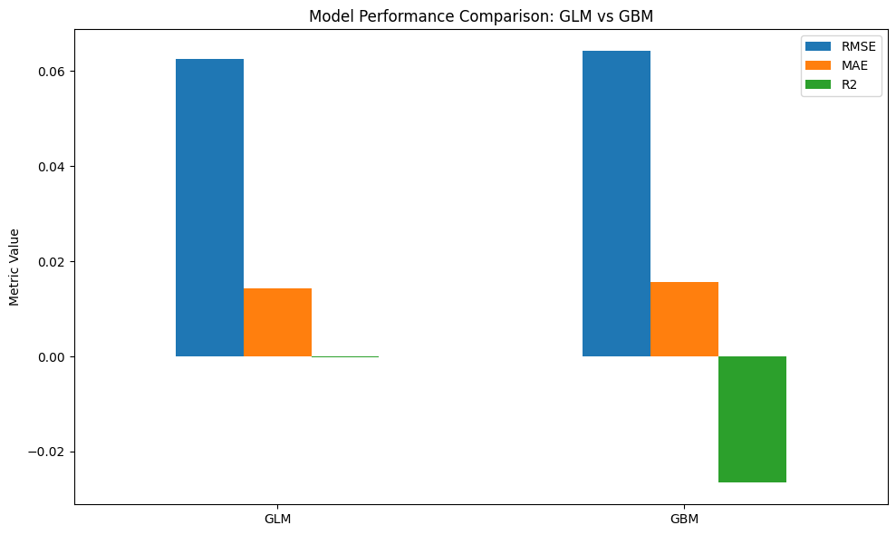

```python
# ======================================================
# Visualize the performance comparison
# ======================================================

ax = results.plot(kind='bar', figsize=(10, 6), rot=0)
ax.set_title('Model Performance Comparison: GLM vs GBM')
ax.set_ylabel('Metric Value')
ax.legend(loc='upper right')
plt.tight_layout()
plt.show()
```

## Model Comparison Summary

The Comparison Table compares the predictive performance of Tweedie GLM and a Gradient Boosting model. The GLM provides a stable and interpretable baseline suitable for insurance loss cost modelling. The Gradient Boosting model offers greater flexibility through non-linear interactions. In this initial analysis, neither model substantially outperforms a mean-based benchmark. This reflects the extreme sparsity and weak signal inherent in the fire-peril loss cost data.